# Mortalité Hospitaliere

Redha TIBA

RStudio

06 08, 2022

# 1 load dada deces

Dans cette partie nous allons travailler sur des données, et utiliser un jeu de données issue de la base de données mysql.

Un data frame (ou tableau de données, ou table) est un type d’objet R qui contient des données au format tabulaire, avec les observations en ligne et les variables en colonnes, comme dans une feuille de tableur de type Excel.

Si on se contente d’exécuter le nom de notre tableau de données R va, comme à son habitude, nous l’afficher dans la console, ce qui est tout sauf utile.

Il est important de comprendre que l’objet data contient l’intégralité des données du tableau. On voit donc qu’un objet peut contenir des données de types très différents (simple nombre, texte, vecteur, tableau de données entier), et être potentiellement de très grande taille

Pour résumer, comme nous avons désormais décidé de saisir nos commandes dans un script et non plus directement dans la console, les premières lignes de notre fichier de travail sur les données de l’enquête sur la mortalité hospitaliere pourraient donc ressembler à ceci :

```r
source("connection_db.R")
source("sig.R")
```

## 1.1 inspect data deces

Un tableau étant un objet comme un autre, on peut lui appliquer des fonctions. Par exemple, nrow et ncol retournent le nombre de lignes et de colonnes du tableau.

La fonction dim renvoie ses dimensions, donc les deux nombres précédents.

La fonction names retourne les noms des colonnes du tableau, c’est-à-dire la liste de nos variables.

Enfin, la fonction str renvoie un descriptif plus détaillé de la structure du tableau. Elle liste les différentes variables, indique leur type 7 et affiche les premières valeurs.

À noter que sous RStudio, on peut afficher à tout moment la structure d’un objet en cliquant sur l’icône de triangle sur fond bleu à gauche du nom de l’objet dans l’onglet Environment.

```r
nrow(data)
```

```
## [1] 6175
```

```r
ncol(data)
```

```
## [1] 14
```

```r
dim(data)
```

```
## [1] 6175   14
```

```r
names(data)
```

```
##  [1] "DINS"          "WILAYAR"       "COMMUNER"      "LD"
##  [5] "STRUCTURED"    "SERVICEHOSPIT" "DUREEHOSPIT"   "SEX"
##  [9] "Years"         "Days"          "Profession"    "CD"
## [13] "CODECIM0"      "CODECIM"
```

```r
#sum(is.na(data))
#colMeans(is.na(data))
```

## 1.2 view data structure deces

### 1.2.1 str

```r
#str(data)
```

### 1.2.2 glimpse

```r
glimpse(data)
```

```
## Rows: 6,175
## Columns: 14
## $ DINS          <date> 2020-01-27, 2020-01-24, 2020-01-24, 2020-01-24, 2020-01~
## $ WILAYAR       <int> 17000, 17000, 17000, 17000, 17000, 17000, 17000, 17000, ~
## $ COMMUNER      <int> 935, 935, 947, 920, 935, 935, 935, 948, 935, 935, 935, 9~
## $ LD            <fct> SSP, DOM, SSP, SSP, SSP, SSP, SSP, SSP, SSP, SSP, SSP, S~
## $ STRUCTURED    <fct> 3, 3, 3, 3, 3, 3, 3, 3, 3, 3, 3, 1, 1, 1, 1, 1, 1, 1, 1,~
## $ SERVICEHOSPIT <fct> 7, 20, 20, 10, 20, 20, 10, 20, 20, 20, 7, 16, 20, 18, 20~
## $ DUREEHOSPIT   <int> 0, 0, 4, 5, 0, 1, 0, 2, 0, 1, 0, 20, 0, 4, 7, 18284, 4, ~
## $ SEX           <fct> M, M, M, F, M, F, M, F, M, M, M, F, M, M, M, F, F, M, M,~
## $ Years         <int> 71, 85, 77, 0, 81, 31, 0, 31, 0, 93, 31, 61, 63, 48, 64,~
## $ Days          <int> 26100, 31101, 28125, 5, 29638, 11678, 0, 11599, 0, 34017~
## $ Profession    <fct> 0, 0, 0, 12, 0, 0, 12, 0, 12, 0, 0, 0, 0, 0, 0, 0, 0, 0,~
## $ CD            <fct> CN, CI, CN, CN, CN, CN, CN, CI, CN, CN, CN, CN, CN, CN, ~
## $ CODECIM0      <int> 10, 18, 10, 16, 6, 18, 16, 18, 1, 4, 14, 10, 9, 10, 2, 9~
## $ CODECIM       <int> 751, 1370, 751, 1145, 517, 1333, 1155, 1370, 35, 407, 10~
```

### 1.2.3 skimr

```r
#library(skimr)
#skim(data)
```

## 1.3 modalité des variable deces

```r
unique(data$LD)
```

```
## [1] SSP  DOM  AAP  VP   SSPV
## Levels: AAP DOM SSP SSPV VP
```

```r
unique(data$SEX)
```

```
## [1] M F
## Levels: F M
```

```r
# Les facteurs prennent leurs valeurs dans un ensemble de modalités prédéfinies
# et ne peuvent enprendre d’autres
levels(data$SEX)
```

```
## [1] "F" "M"
```

```r
unique(data$Profession)
```

```
##  [1] 0  12 1  13 7  11 14 3  6  4  20 19 16 5
## Levels: 0 1 3 4 5 6 7 9 11 12 13 14 15 16 19 20
```

```r
unique(data$CD)
```

```
## [1] CN CI CV
## Levels: CI CN CV
```

## 1.4 Accéder aux valeurs des variables d’un tableau

La fonction table$colonne renvoie donc la colonne nommée colonne du tableau table, c’est-à-dire un vecteur, en général de nombres ou de chaînes de caractères.

```r
## data$DINS
```

## 1.5 look_for

```r
#look_for(data)
```

## 1.6 tbl_summary

```r
tbl_summary(data)
```

| **Characteristic** | **N = 6,175**<sup>1</sup> |
| --- | --- |
| Date du décès | 2020-01-01 to 2021-12-31 |
| Wilaya de résidence | 17,150 (1,992) |
| Commune de résidence | 934 (110) |
| Lieux du décès |  |
| AAP | 348 (5.6%) |
| DOM | 497 (8.0%) |
| SSP | 5,237 (85%) |
| SSPV | 6 (<0.1%) |
| VP | 87 (1.4%) |
| Structure sanitaire |  |
| 1 | 1,591 (26%) |
| 2 | 1,205 (20%) |
| 3 | 905 (15%) |
| 4 | 746 (12%) |
| 5 | 727 (12%) |
| 6 | 312 (5.1%) |
| 7 | 206 (3.3%) |
| 8 | 0 (0%) |
| 18 | 411 (6.7%) |
| 19 | 72 (1.2%) |
| Service d'hospitalisation |  |
| 0 | 128 (2.1%) |
| 1 | 11 (0.2%) |
| 2 | 77 (1.2%) |
| 3 | 1 (<0.1%) |
| 4 | 0 (0%) |
| 5 | 40 (0.6%) |
| 6 | 465 (7.5%) |
| 7 | 424 (6.9%) |
| 8 | 15 (0.2%) |
| 9 | 4 (<0.1%) |
| 10 | 1,225 (20%) |
| 11 | 5 (<0.1%) |
| 12 | 1 (<0.1%) |
| 14 | 0 (0%) |
| 15 | 138 (2.2%) |
| 16 | 173 (2.8%) |
| 17 | 0 (0%) |
| 18 | 468 (7.6%) |
| 19 | 1 (<0.1%) |
| 20 | 2,342 (38%) |
| 21 | 639 (10%) |
| 24 | 1 (<0.1%) |
| 25 | 17 (0.3%) |
| Durée d'hospitalisation | 881 (3,912) |
| Sexe |  |
| F | 2,566 (42%) |
| M | 3,609 (58%) |
| Age (Année) | 49 (34) |
| Age (Jours) | 17,869 (12,569) |
| Profession |  |
| 0 | 2,951 (48%) |
| 1 | 1,980 (32%) |
| 3 | 3 (<0.1%) |
| 4 | 4 (<0.1%) |
| 5 | 1 (<0.1%) |
| 6 | 11 (0.2%) |
| 7 | 16 (0.3%) |
| 9 | 0 (0%) |
| 11 | 36 (0.6%) |
| 12 | 200 (3.2%) |
| 13 | 266 (4.3%) |
| 14 | 6 (<0.1%) |
| 15 | 0 (0%) |
| 16 | 4 (<0.1%) |
| 19 | 205 (3.3%) |
| 20 | 492 (8.0%) |
| Cause du décès |  |
| CI | 351 (5.7%) |
| CN | 5,621 (91%) |
| CV | 203 (3.3%) |
| Capitre CIM10 | 9 (6) |
| Titre CIM10 | 690 (474) |

<sup>1</sup> Range; Mean (SD); n (%)

## 1.7 summary data deces

```r
summary(data)
```

```
##       DINS               WILAYAR         COMMUNER         LD
##  Min.   :2020-01-01   Min.   : 1000   Min.   :   1.0   AAP : 348
##  1st Qu.:2020-07-19   1st Qu.:17000   1st Qu.: 916.0   DOM : 497
##  Median :2021-02-10   Median :17000   Median : 924.0   SSP :5237
##  Mean   :2021-01-23   Mean   :17150   Mean   : 934.1   SSPV:   6
##  3rd Qu.:2021-08-07   3rd Qu.:17000   3rd Qu.: 935.0   VP  :  87
##  Max.   :2021-12-31   Max.   :47000   Max.   :2291.0
##
##    STRUCTURED   SERVICEHOSPIT   DUREEHOSPIT      SEX          Years
##  1      :1591   20     :2342   Min.   :-3580.0   F:2566   Min.   :  0.00
##  2      :1205   10     :1225   1st Qu.:    0.0   M:3609   1st Qu.:  0.00
##  3      : 905   21     : 639   Median :    1.0            Median : 60.00
##  4      : 746   18     : 468   Mean   :  881.3            Mean   : 48.52
##  5      : 727   6      : 465   3rd Qu.:    5.0            3rd Qu.: 79.00
##  18     : 411   7      : 424   Max.   :29220.0            Max.   :100.00
##  (Other): 590   (Other): 612
##       Days           Profession    CD          CODECIM0         CODECIM
##  Min.   : -279.0   0      :2951   CI: 351   Min.   : 0.000   Min.   :   0.0
##  1st Qu.:  325.5   1      :1980   CN:5621   1st Qu.: 2.000   1st Qu.: 217.0
##  Median :22257.0   20     : 492   CV: 203   Median :10.000   Median : 709.0
##  Mean   :17868.9   13     : 266             Mean   : 9.201   Mean   : 690.2
##  3rd Qu.:28883.5   19     : 205             3rd Qu.:16.000   3rd Qu.:1154.0
##  Max.   :36857.0   12     : 200             Max.   :21.000   Max.   :2039.0
##                    (Other):  81
```

## 1.8 view data deces

Si on souhaite afficher seulement les premières ou dernières valeurs d’une variable, on peut utiliser les fonctions head et tail.

Le deuxième argument numérique permet d’indiquer le nombre de valeurs à afficher.

### 1.8.1 head

```r
head(data,6)
```

```
##         DINS WILAYAR COMMUNER  LD STRUCTURED SERVICEHOSPIT DUREEHOSPIT SEX
## 1 2020-01-27   17000      935 SSP          3             7           0   M
## 2 2020-01-24   17000      935 DOM          3            20           0   M
## 3 2020-01-24   17000      947 SSP          3            20           4   M
## 4 2020-01-24   17000      920 SSP          3            10           5   F
## 5 2020-01-22   17000      935 SSP          3            20           0   M
## 6 2020-01-22   17000      935 SSP          3            20           1   F
##   Years  Days Profession CD CODECIM0 CODECIM
## 1    71 26100          0 CN       10     751
## 2    85 31101          0 CI       18    1370
## 3    77 28125          0 CN       10     751
## 4     0     5         12 CN       16    1145
## 5    81 29638          0 CN        6     517
## 6    31 11678          0 CN       18    1333
```

### 1.8.2 tail

```r
tail(data,6)
```

```
##            DINS WILAYAR COMMUNER  LD STRUCTURED SERVICEHOSPIT DUREEHOSPIT SEX
## 6170 2021-05-06   17000      929 SSP         19            21        -300   M
## 6171 2021-04-28   17000      929  VP         19            21        -326   M
## 6172 2021-01-19   17000      929 DOM         19            21        -414   M
## 6173 2021-04-15   17000      929 SSP         19            20           0   M
## 6174 2021-05-22   17000      929 DOM         19            21        -302   M
## 6175 2021-12-24   17000      916 SSP          5            21           0   F
##      Years  Days Profession CD CODECIM0 CODECIM
## 6170     0     2          1 CN        0       0
## 6171    17  6447          1 CI        0       0
## 6172    82 29970          1 CN        2     253
## 6173    15  5839          1 CN        0       0
## 6174    84 30823          1 CN        0       0
## 6175    37 13739          1 CN        0       0
```

### 1.8.3 View

```r
#View(data)
```

# 2 Analyse univariée

On a donc désormais accès à un tableau de données data, dont :

- les lignes sont des observations (des individus enquêtés)
- les colonnes des variables (des caractéristiques de chacun de ces individus), et on sait accéder à ces variables grâce à l’opérateur $.

Si on souhaite analyser ces variables, les méthodes et fonctions utilisées seront différentes selon qu’il s’agit

- d’une variable quantitative (variable numérique pouvant prendre un grand nombre de valeurs)
- d’une variable qualitative (variable pouvant prendre un nombre limité de valeurs appelées modalités).

## 2.1 Temps

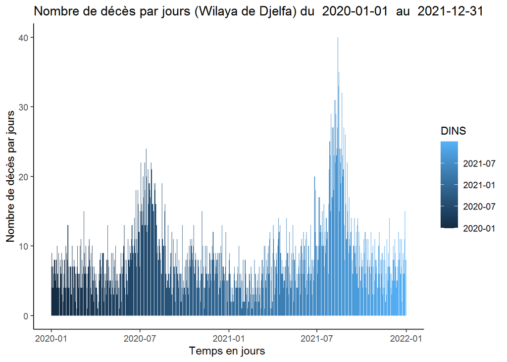

```r
ts <- data %>%
      select(DINS) %>%
      group_by(DINS) %>%
      summarise(number_year = n()) %>%
      arrange(DINS) #%>%

ts %>%
ggplot(aes(x = DINS, y = number_year, fill = DINS)) +
    #geom_line(color="red") +
    geom_bar(stat = "identity") +
    theme_classic() +
    labs(
        x = "Temps en jours ",
        y = "Nombre de décès par jours",
        title = paste("Nombre de décès par jours (Wilaya de Djelfa) du ",dt1," au ",dt2)
        )
```

## 2.2 lieux du deces

### 2.2.1 SIG Deces par wilaya de Résidence

```r
data %>%
  select(DINS,WILAYAR) %>%
  group_by(WILAYAR) %>%
  summarise(number_wil = n()) %>%
  arrange(desc(number_wil)) %>%
  mutate(CC_1=recode(WILAYAR,
                    "1000" = "1",
                    "2000" = "2",
                    "3000" = "3",
                    "4000" = "4",
                    "5000" = "5",
                    "6000" = "6",
                    "7000" = "7",
                    "8000" = "8",
                    "9000" = "9",
                    "10000" = "10",
                    "11000" = "11",
                    "12000" = "12",
                    "13000" = "13",
                    "14000" = "14",
                    "15000" = "15",
                    "16000" = "16",
                    "17000" = "17",
                    "18000" = "18",
                    "19000" = "19",
                    "20000" = "20",
                    "21000" = "21",
                    "22000" = "22",
                    "23000" = "23",
                    "24000" = "24",
                    "25000" = "25",
                    "26000" = "26",
                    "27000" = "27",
                    "28000" = "28",
                    "29000" = "29",
                    "30000" = "30",
                    "31000" = "31",
                    "32000" = "32",
                    "33000" = "33",
                    "34000" = "34",
                    "35000" = "35",
                    "36000" = "36",
                    "37000" = "37",
                    "38000" = "38",
                    "39000" = "39",
                    "40000" = "40",
                    "41000" = "41",
                    "42000" = "42",
                    "43000" = "43",
                    "44000" = "44",
                    "45000" = "45",
                    "46000" = "46",
                    "47000" = "47",
                    "48000" = "48"
                    ))-> df
```

### 2.2.2 SIG Deces par wilaya de Résidence:map

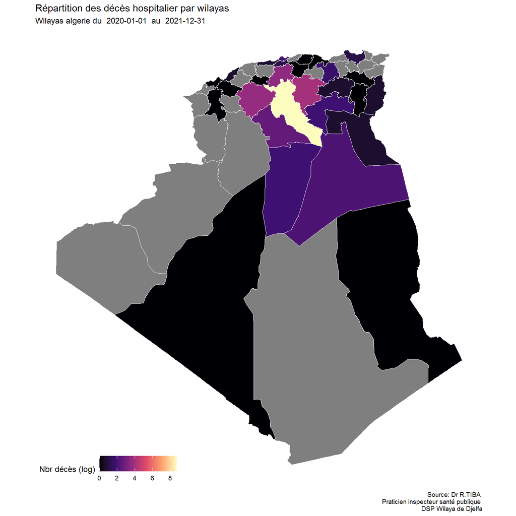

```r
deces_w_djelfa <-left_join(w_algeria, df, by='CC_1')
wdjelfa <- deces_w_djelfa %>%
  select(NAME_1,CC_1,number_wil) %>%
  mutate(number_wil = log(number_wil))

ggplot()+
  geom_sf(data=wdjelfa,aes(fill=number_wil), color = "white", lwd = 0.05) +
    scale_fill_viridis_c(option = "magma", name = "Nbr décès (log)") +
    theme_map() +
    theme(legend.direction="horizontal") +
     labs(title = "Répartition des décès hospitalier par wilayas",
         subtitle = paste("Wilayas algerie du ",dt1," au ",dt2),
         caption = "Source: Dr R.TIBA \n Praticien inspecteur santé publique \n DSP Wilaya de Djelfa")+
  coord_sf(crs = "+proj=robin")
```

### 2.2.3 SIG Deces par commune de Résidence

```r
data %>%
  select(DINS,WILAYAR,COMMUNER) %>%
  filter(WILAYAR == 17000)  %>%
  group_by(COMMUNER) %>%
  summarise(number_com = n()) %>%
  arrange(desc(number_com)) %>%
  mutate(CC_2=recode(COMMUNER,
                    "916" = "1701",#djelfa
                    "917" = "1714",#el idrissia
                    "919" = "1703",#919 El Guedid
                    "920" = "1726",#920 Charef
                    "923" = "1727",#923 Beni Yacoub
                    "924" = "1731",#924 Ain Oussera
                    "925" = "1721",#925 Guernini
                    "926" = "1719",#926 Sidi Ladjel
                    "927" = "1733",#927 Hassi Fedoul
                    "928" = "1711",#928 El Khemis
                    "929" = "1708",#929 Birine
                    "931" = "1732",#931 Benhar
                    "932" = "1720",#932 Had-Sahary
                    "933" = "1709",#933 Bouira Lahdab
                    "934" = "1735",#934 Ain Fekka
                    "935" = "1704",#935 Hassi Bahbah
                    "939" = "1728",#939 Zaafrane
                    "940" = "1716",#940 Hassi el Euch
                    "941" = "1705",#941 Ain Maabed
                    "942" = "1725",#942 Dar Chioukh
                    "946" = "1713",#946 MLiliha
                    "947" = "1712",#947 Sidi Baizid
                    "948" = "1717",#948 Messad
                    "951" = "1718",#951 Guettara
                    "952" = "1729",#952 Deldoul
                    "953" = "1706",#953 Sed Rahal
                    "954" = "1722",#954 Selmana
                    "956" = "1724",#956 Oum Laadham
                    "957" = "1702",#957 Mouadjebar
                    "958" = "1730",#958 Ain el Ibel
                    "962" = "1710",#962 Zaccar
                    "963" = "1715",#963 Douis
                    "964" = "1723",#964 Ain Chouhada
                    "965" = "1736",#965 Tadmit
                    "967" = "1707",#967 Faidh el Botma
                    "968" = "1734" #968 Amourah
                    ))-> dfc
```

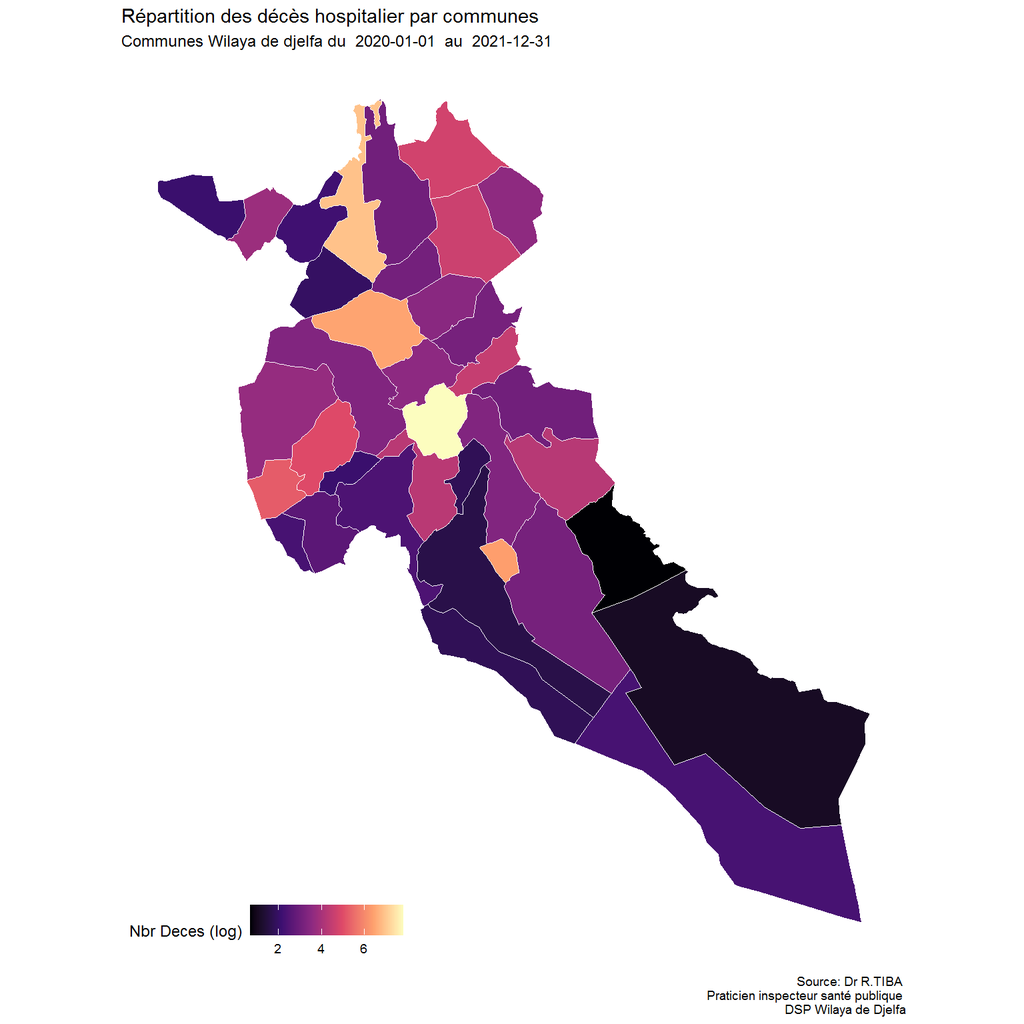

```r
deces_c_djelfa <-left_join(wc_algeria, dfc, by='CC_2')
#x = djelfa, y = dataext, by.x = "IDC", by.y = "IDC"
cdjelfa <- deces_c_djelfa %>%
  filter(NAME_1=="Djelfa") %>%
  select(NAME_1,CC_2,number_com) %>%
  mutate(number_com = log(number_com))

ggplot()+
  geom_sf(data=cdjelfa,aes(fill=number_com), color = "white", lwd = 0.05) +
    scale_fill_viridis_c(option = "magma", name = "Nbr Deces (log)") +
    theme_map() +
    theme(legend.direction="horizontal") +
     labs(title = "Répartition des décès hospitalier par communes",
         subtitle = paste("Communes Wilaya de djelfa du ",dt1," au ",dt2),
         caption = "Source: Dr R.TIBA \n Praticien inspecteur santé publique \n DSP Wilaya de Djelfa")+
  coord_sf(crs = "+proj=robin")
```

### 2.2.4 lieux:table

```r
lieux <- table(data$LD)#,useNA = "always"
sort(lieux)
```

```
##
## SSPV   VP  AAP  DOM  SSP
##    6   87  348  497 5237
```

```r
summary(lieux)
```

```
## Number of cases in table: 6175
## Number of factors: 1
```

### 2.2.5 lieux:graphic:r-base

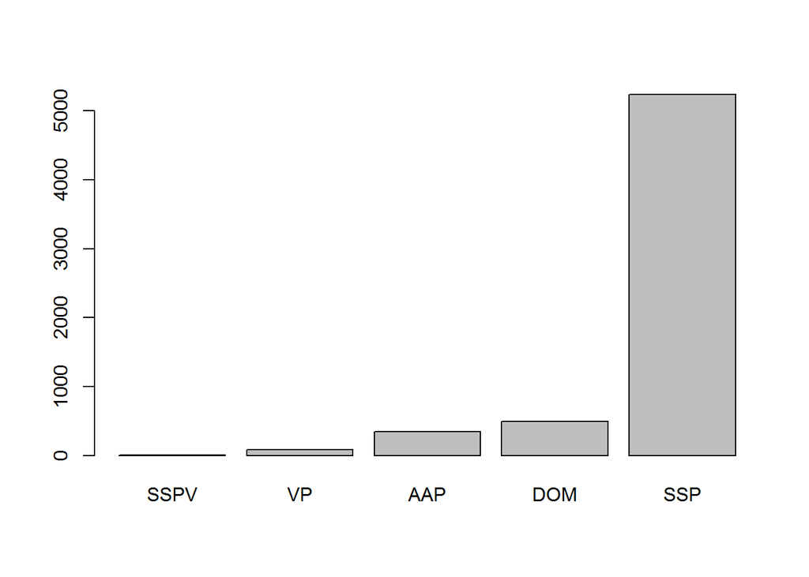

```r
barplot(sort(lieux))
```

### 2.2.6 lieux:grafic:r-ggplot2

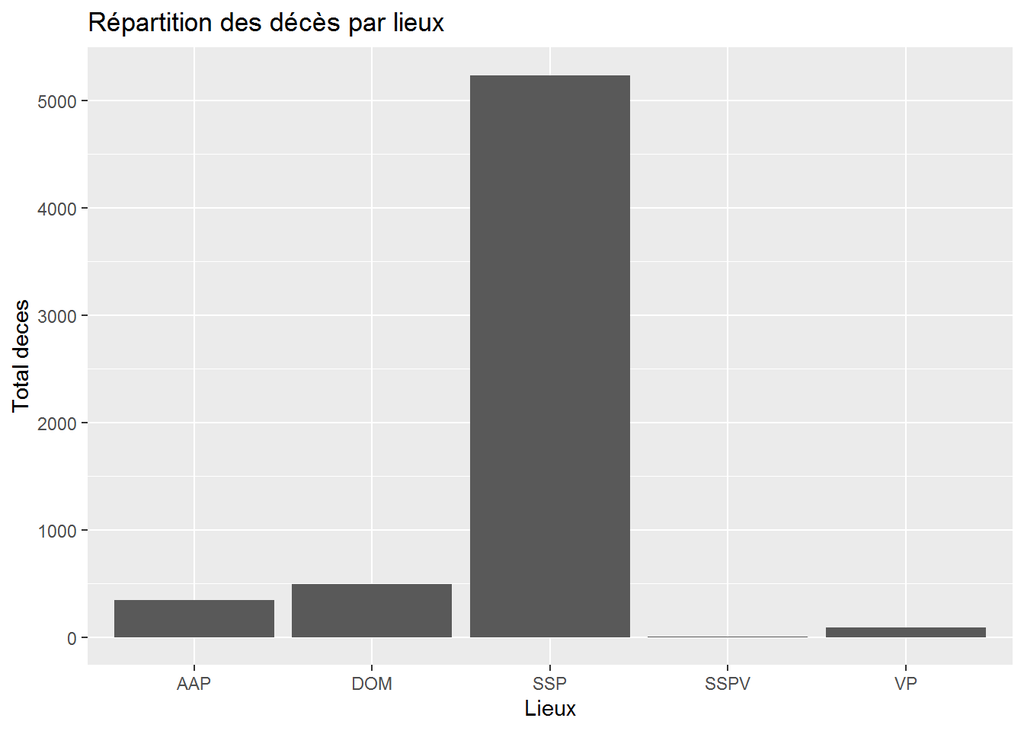

```r
ggplot(data = data, mapping = aes(x = LD)) +
  geom_bar()+
  labs(title = "Répartition des décès par lieux",
       x = "Lieux",
       y = "Total deces")
```

## 2.3 structure sanitaire

### 2.3.1 structure:table

```r
structure <- table(data$STRUCTURED)#,useNA = "always"
sort(structure)
```

```
##
##    8   19    7    6   18    5    4    3    2    1
##    0   72  206  312  411  727  746  905 1205 1591
```

```r
summary(structure)
```

```
## Number of cases in table: 6175
## Number of factors: 1
```

### 2.3.2 structure:graphic r-base

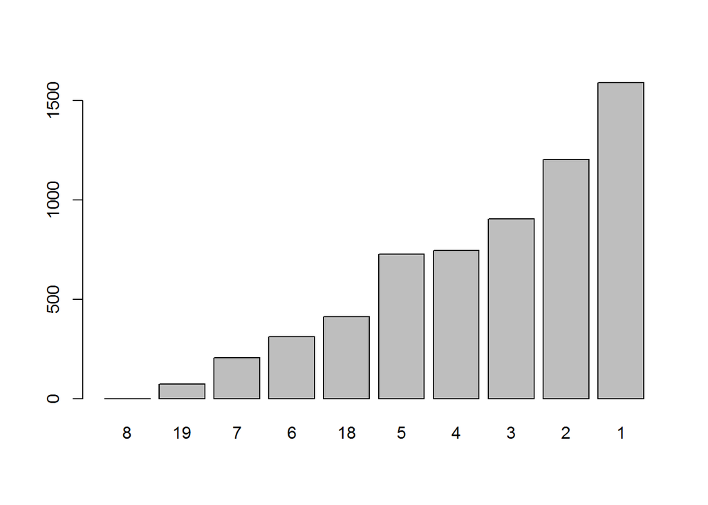

```r
barplot(sort(structure))
```

### 2.3.3 structure:graphic:r-ggplot2

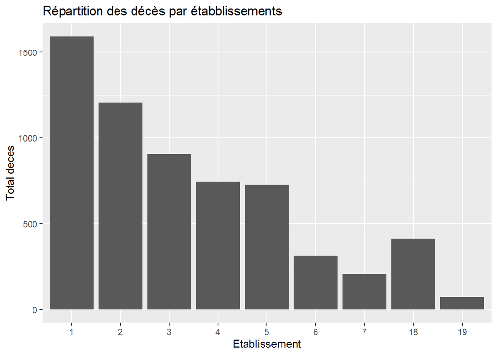

```r
ggplot(data = data, mapping = aes(x = STRUCTURED)) +
  geom_bar()+
  labs(title = "Répartition des décès par étabblissements",
       x = "Etablissement",
       y = "Total deces")
```

## 2.4 service du deces

### 2.4.1 service:table

```r
service <- table(data$SERVICEHOSPIT)#,useNA = "always"
sort(service)
```

```
##
##    4   14   17    3   12   19   24    9   11    1    8   25    5    2    0   15
##    0    0    0    1    1    1    1    4    5   11   15   17   40   77  128  138
##   16    7    6   18   21   10   20
##  173  424  465  468  639 1225 2342
```

```r
summary(service)
```

```
## Number of cases in table: 6175
## Number of factors: 1
```

### 2.4.2 service:graphic:r-base

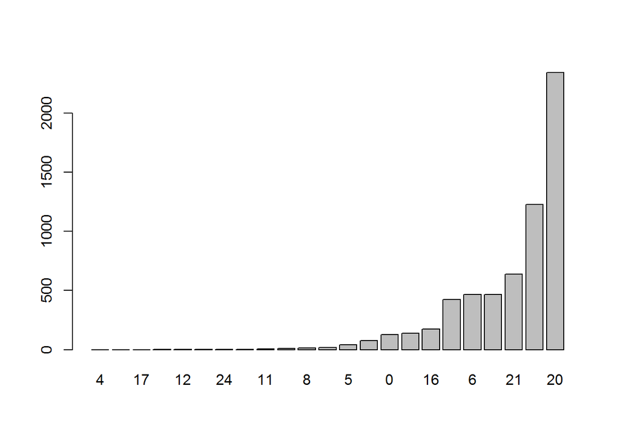

```r
barplot(sort(service))
```

### service:graphic:r-ggplot2

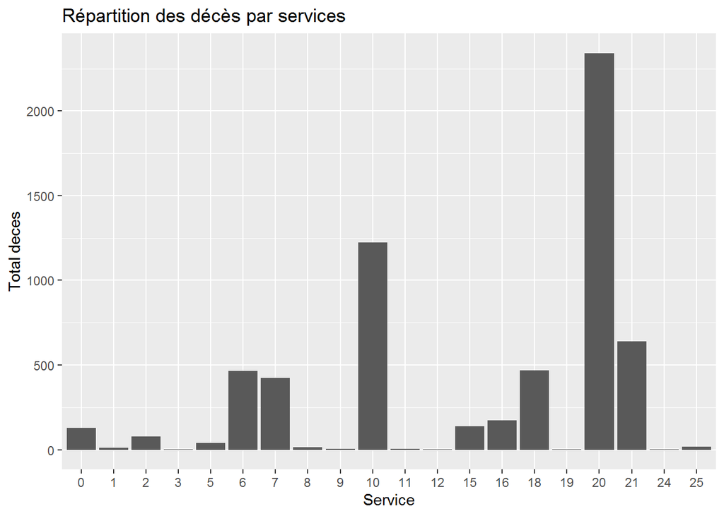

```r
ggplot(data = data, mapping = aes(x = SERVICEHOSPIT)) +
  geom_bar()+
  labs(title = "Répartition des décès par services",
       x = "Service",
       y = "Total deces")
```

## 2.5 age en année

### 2.5.1 age:table

```r
#clag <- c(0,5,10,15,20,25,30,35,40,45,50,55,60,65,70,75,80,85,90,95,100)
clag <- c(0,10,20,30,40,50,60,70,80,90,100)
data$age20cl <- cut(data$Years,clag,include.lowest = TRUE)
table(data$age20cl)
```

```
##
##   [0,10]  (10,20]  (20,30]  (30,40]  (40,50]  (50,60]  (60,70]  (70,80]
##     1724      108      174      235      343      508      800      936
##  (80,90] (90,100]
##     1068      279
```

```r
#age <- table(data$Years)#,useNA = "always"
#sort(age)
#summary(age)
```

### 2.5.2 age:grafic:r-base

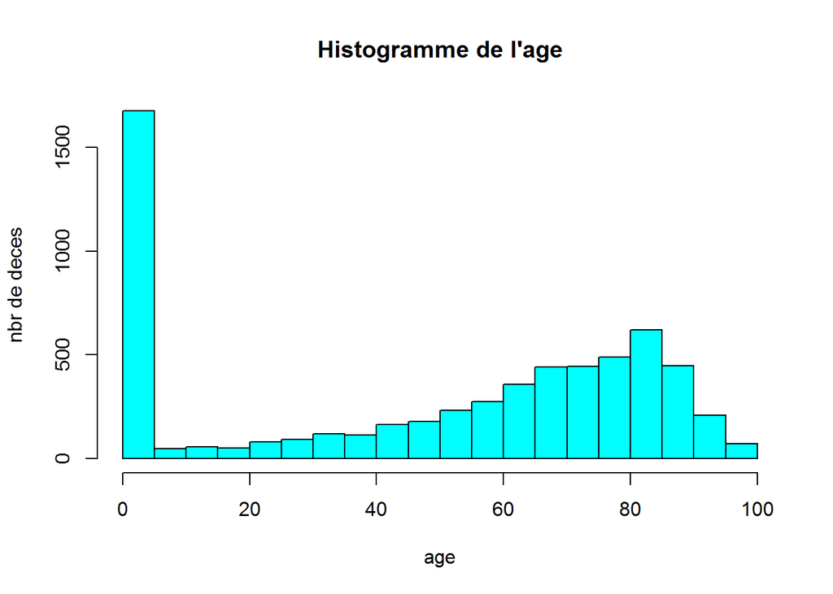

```r
hist(data$Years,
     main = "Histogramme de l'age",
     xlab = "age",
     ylab= "nbr de deces",
     breaks = 15,
     col = "cyan")
```

### 2.5.3 age:grafic:r-base

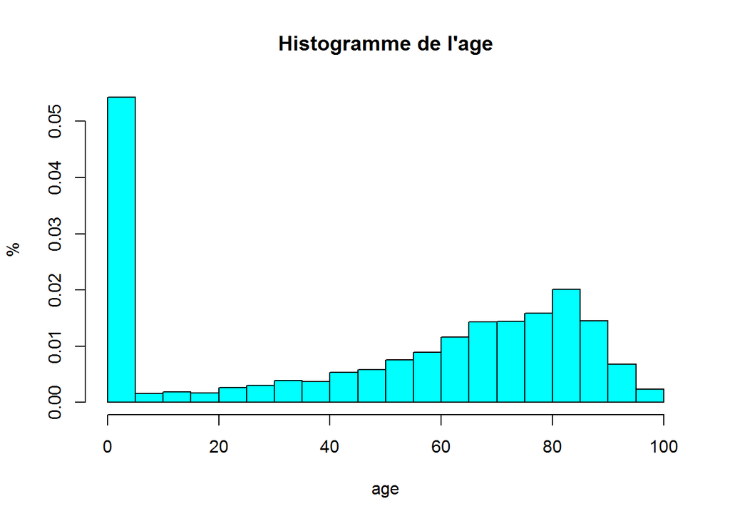

```r
hist(data$Years,
     main = "Histogramme de l'age",
     xlab = "age",
     ylab= "%",
     breaks = 15,
     col = "cyan",
     probability = TRUE)
```

### 2.5.4 age:grafic:r-base

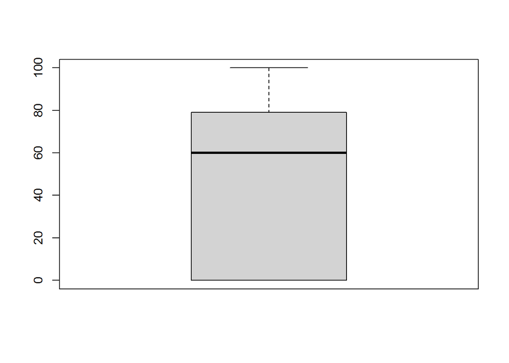

```r
boxplot(data$Years)
```

### 2.5.5 age:grafic:t-ggplot2

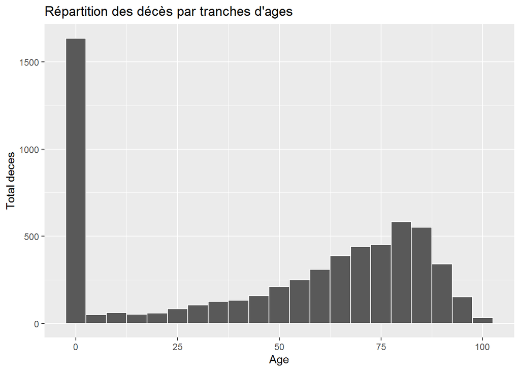

```r
ggplot(data = data, mapping = aes(x = Years)) + #, fill = data$SEX
  geom_histogram(binwidth = 5, color = "white")+
  labs(title = "Répartition des décès par tranches d'ages",
       x = "Age",
       y = "Total deces")
```

### age:grafic:t-ggplot2

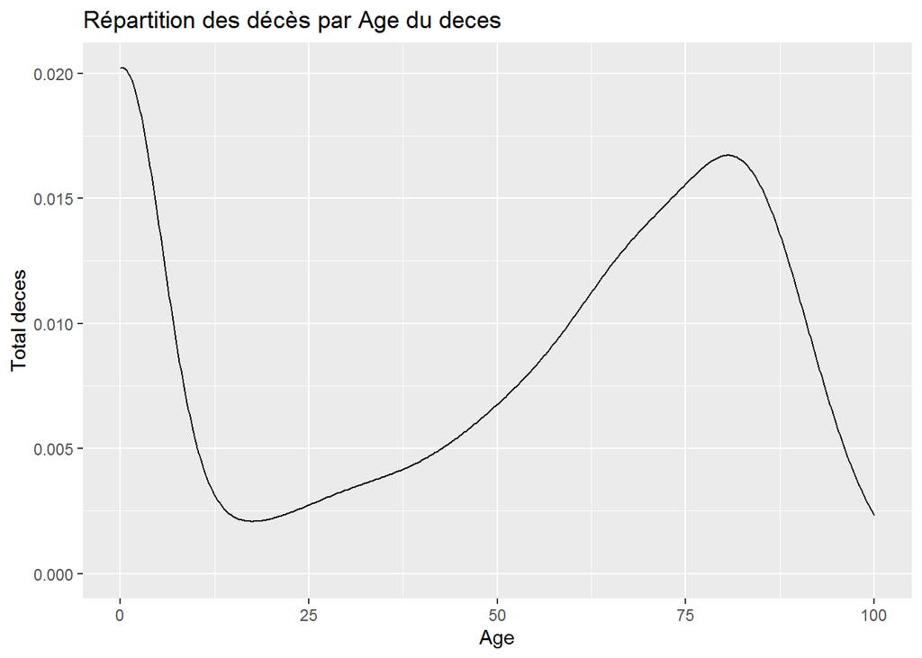

```r
ggplot(data = data, mapping = aes(x = Years)) + #, fill = data$SEX
  geom_density()+
  labs(title = "Répartition des décès par Age du deces",
       x = "Age",
       y = "Total deces")
```

### 2.5.6 age:grafic:t-ggplot2

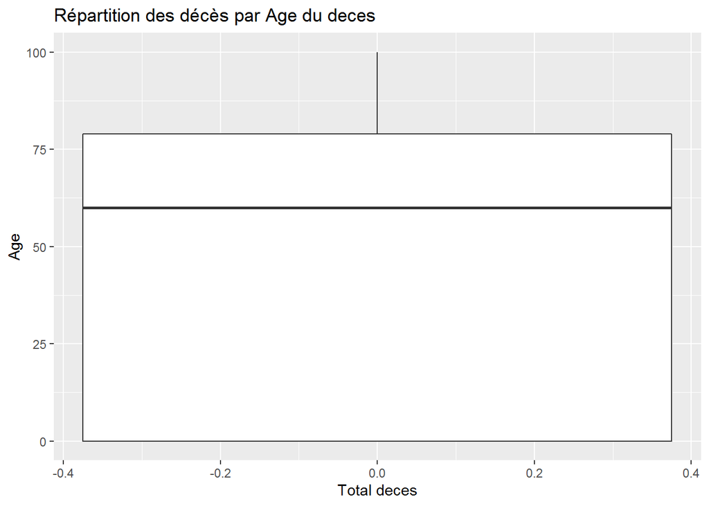

```r
ggplot(data = data, mapping = aes(y = Years)) + #, fill = data$SEX
  geom_boxplot()+
  labs(title = "Répartition des décès par Age du deces",
       x = "Total deces",
       y = "Age")
```

## sexe

### 2.5.7 sexe:table

```r
sexe <- table(data$SEX)#,useNA = "always"
sort(sexe)
```

```
##
##    F    M
## 2566 3609
```

```r
summary(sexe)
```

```
## Number of cases in table: 6175
## Number of factors: 1
```

### 2.5.8 sexe:graphic r-base

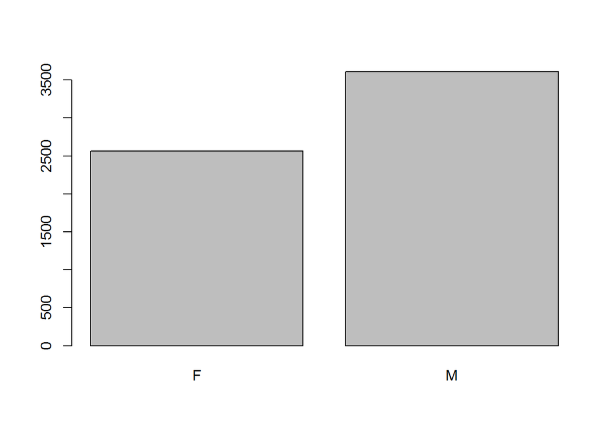

```r
barplot(sort(sexe))
```

### sexe:graphic r-ggplot2

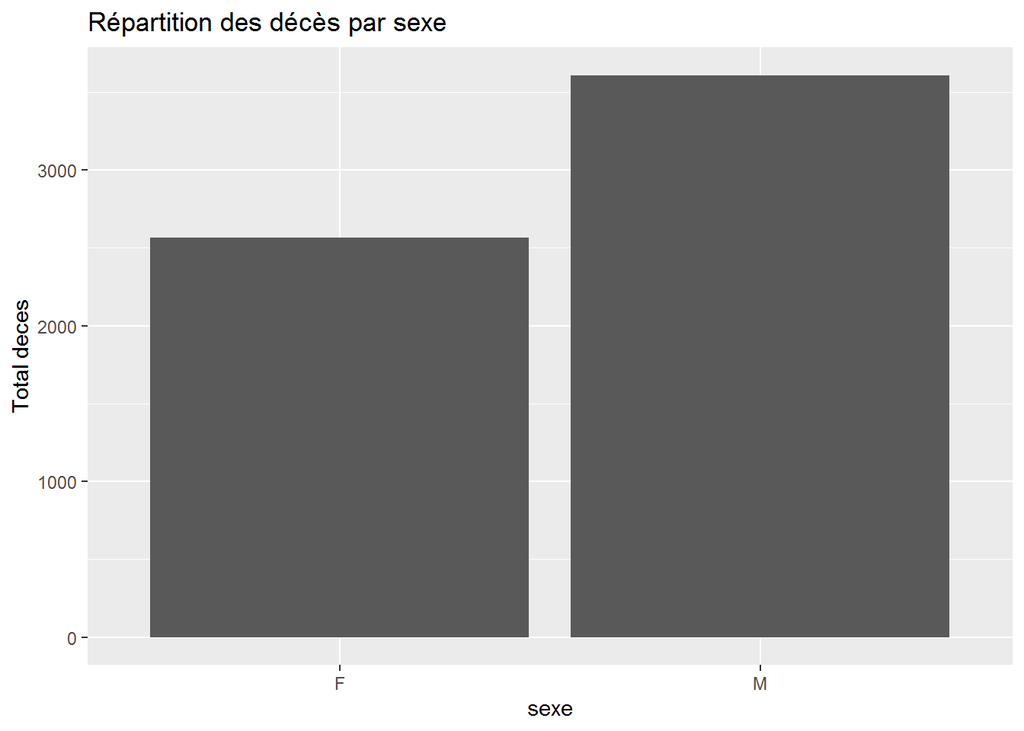

```r
ggplot(data = data, mapping = aes(x = SEX)) +
  geom_bar()+
  labs(title = "Répartition des décès par sexe",
       x = "sexe",
       y = "Total deces")
```

## 2.6 Profession

### 2.6.1 profession:table

```r
Profession <- table(data$Profession)#,useNA = "always"
sort(Profession)
```

```
##
##    9   15    5    3    4   16   14    6    7   11   12   19   13   20    1    0
##    0    0    1    3    4    4    6   11   16   36  200  205  266  492 1980 2951
```

```r
summary(Profession)
```

```
## Number of cases in table: 6175
## Number of factors: 1
```

### 2.6.2 profession:graphic r-base

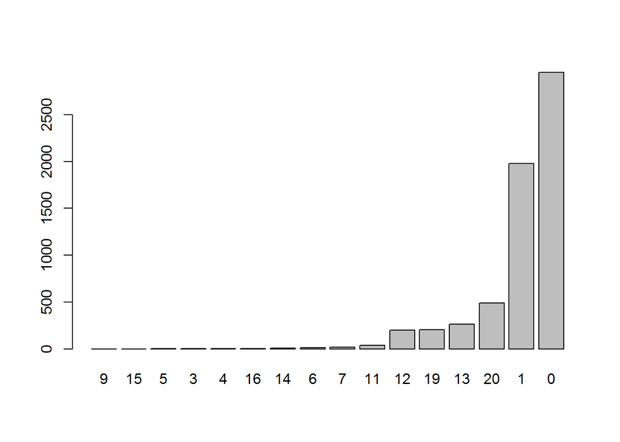

```r
barplot(sort(Profession))
```

### profession:graphic r-ggplot2

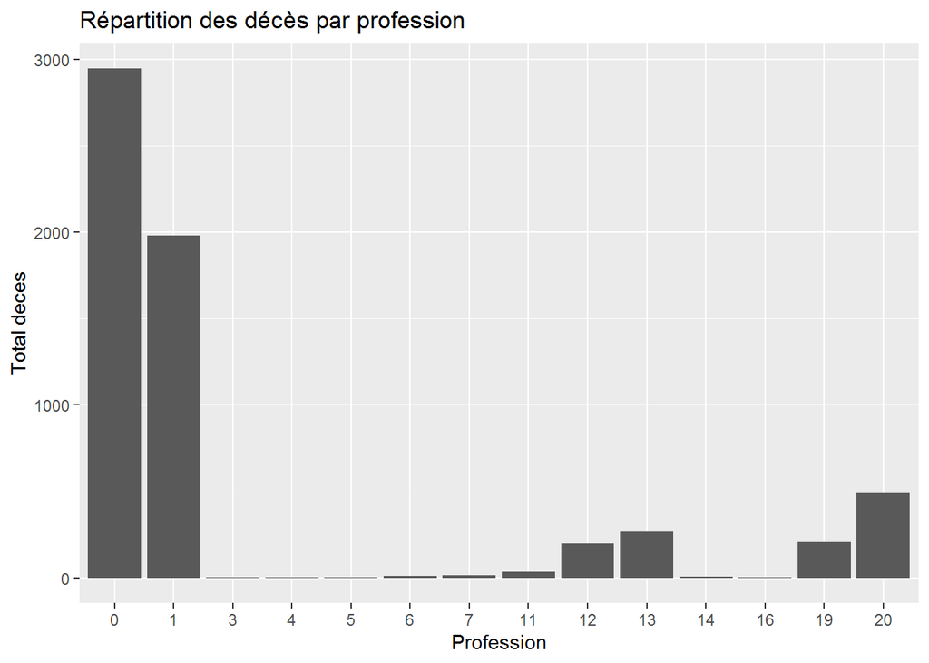

```r
ggplot(data = data, mapping = aes(x = Profession)) +
  geom_bar()+
  labs(title = "Répartition des décès par profession",
       x = "Profession",
       y = "Total deces")
```

## 2.7 repartition des deces par chapitre CIM10

```r
table(data$CODECIM0)
```

```
##
##    0    1    2    3    4    5    6    8    9   10   11   12   13   14   15   16
## 1137  270  241   38  104    3   75    2  902 1398  120    3    8  124   16  825
##   17   18   19   20   21
##  237  525  102   43    2
```

## 2.8 repartition des deces par titre CIM10

```r
#table(data$CODECIM)
```

# 3 Analyse bivariée

Faire une analyse bivariée, c’est étudier la relation entre deux variables : sont-elles liées ? les valeurs de l’une influencent-elles les valeurs de l’autre ? ou sont-elles au contraire indépendantes ?

À noter qu’on va parler ici d’influence ou de lien, mais pas de relation de cause à effet. Les outils présentés permettent de visualiser ou de déterminer une relation, mais la mise en évidence de liens de causalité proprement dit est nettement plus complexe : il faut en effet vérifier que c’est bien telle variable qui influence telle autre et pas l’inverse, qu’il n’y a pas de “variable cachée”, etc.

Là encore, le type d’analyse ou de visualisation est déterminé par la nature qualitative ou quantitative des deux variables.

## 3.1 Croisement de deux variables qualitatives

Quand on veut croiser deux variables qualitatives, on fait un tableau croisé. Comme pour un tri à plat ceci s’obtient avec la fonction table de R, mais à laquelle on passe cette fois deux variables en argument.

### 3.1.1 lieux du deces et le sexe

```r
table(data$LD, data$SEX)
```

```
##
##           F    M
##   AAP   122  226
##   DOM   214  283
##   SSP  2209 3028
##   SSPV    4    2
##   VP     17   70
```

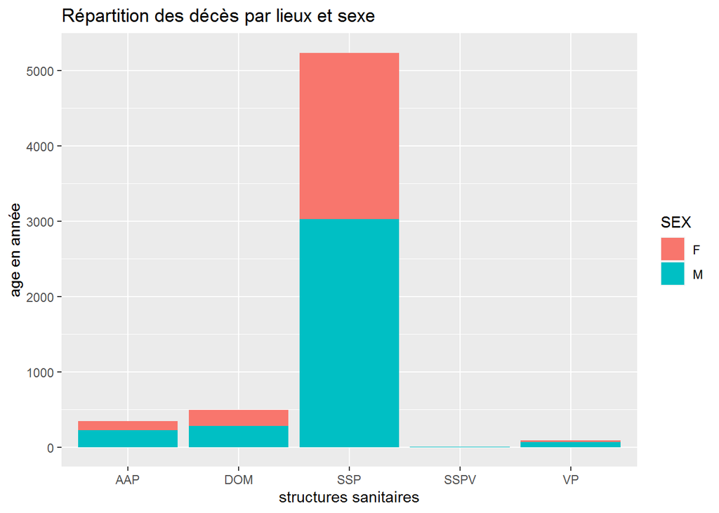

```r
ggplot(data = data) +
  geom_bar(aes(x = LD, fill = SEX))+
  labs(title = "Répartition des décès par lieux et sexe",
       x = "structures sanitaires",
       y = "age en année")
```

### 3.1.2 causes du deces et le sexe

```r
table(data$CD, data$SEX)
```

```
##
##         F    M
##   CI  137  214
##   CN 2388 3233
##   CV   41  162
```

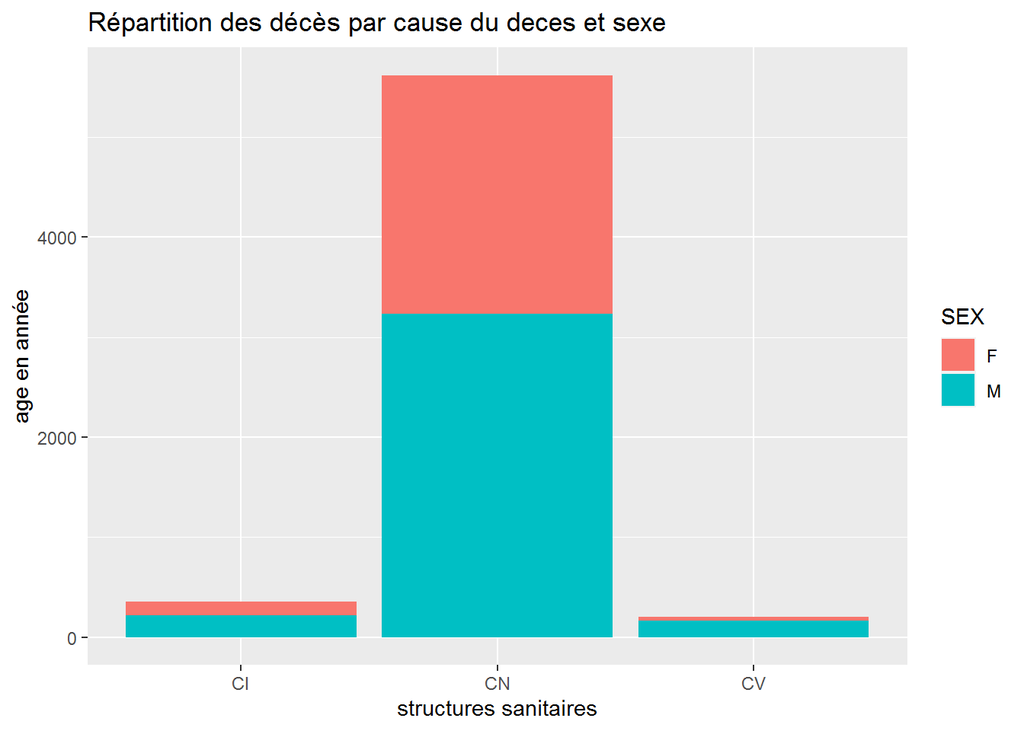

```r
ggplot(data = data) +
  geom_bar(aes(x = CD, fill = SEX))+
  labs(title = "Répartition des décès par cause du deces et sexe",
       x = "structures sanitaires",
       y = "age en année")
```

### 3.1.3 la profession du deces et le sexe

```r
table(data$Profession, data$SEX)
```

```
##
##         F    M
##   0  1087 1864
##   1   812 1168
##   3     0    3
##   4     0    4
##   5     0    1
##   6     4    7
##   7     0   16
##   9     0    0
##   11    2   34
##   12   89  111
##   13  263    3
##   14    2    4
##   15    0    0
##   16    2    2
##   19   91  114
##   20  214  278
```

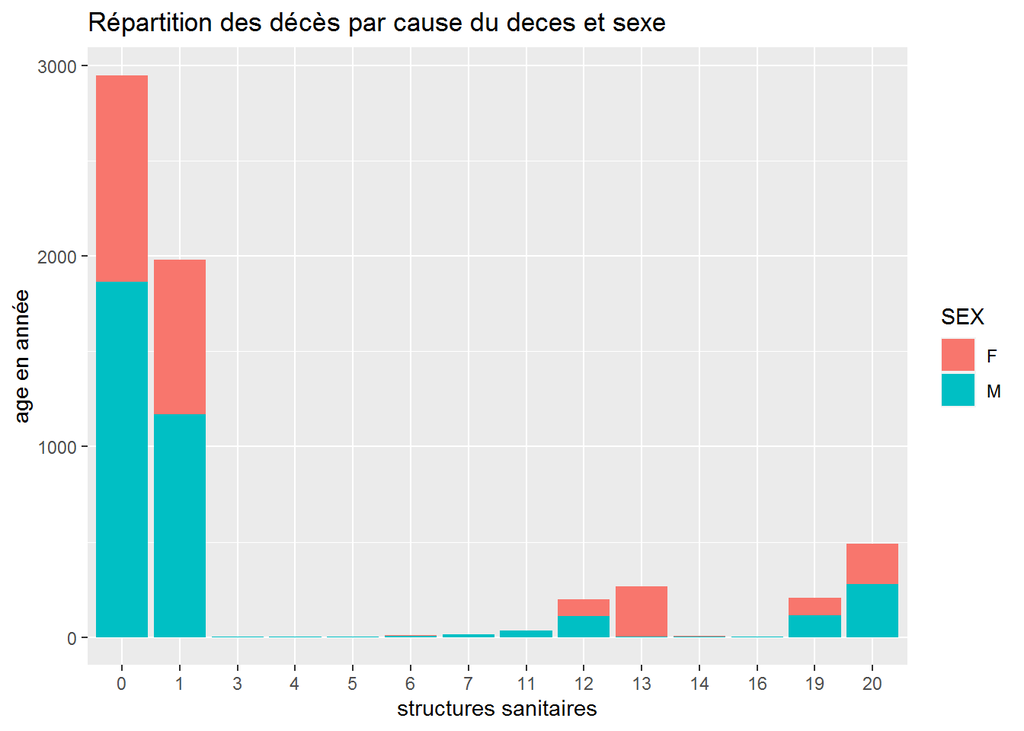

```r
ggplot(data = data) +
  geom_bar(aes(x = Profession, fill = SEX))+
  labs(title = "Répartition des décès par cause du deces et sexe",
       x = "structures sanitaires",
       y = "age en année")
```

### 3.1.4 la structure sanitaire du deces et le sexe

```r
table(data$STRUCTURED, data$SEX)
```

```
##
##        F   M
##   1  644 947
##   2  508 697
##   3  385 520
##   4  322 424
##   5  303 424
##   6  139 173
##   7   90 116
##   8    0   0
##   18 157 254
##   19  18  54
```

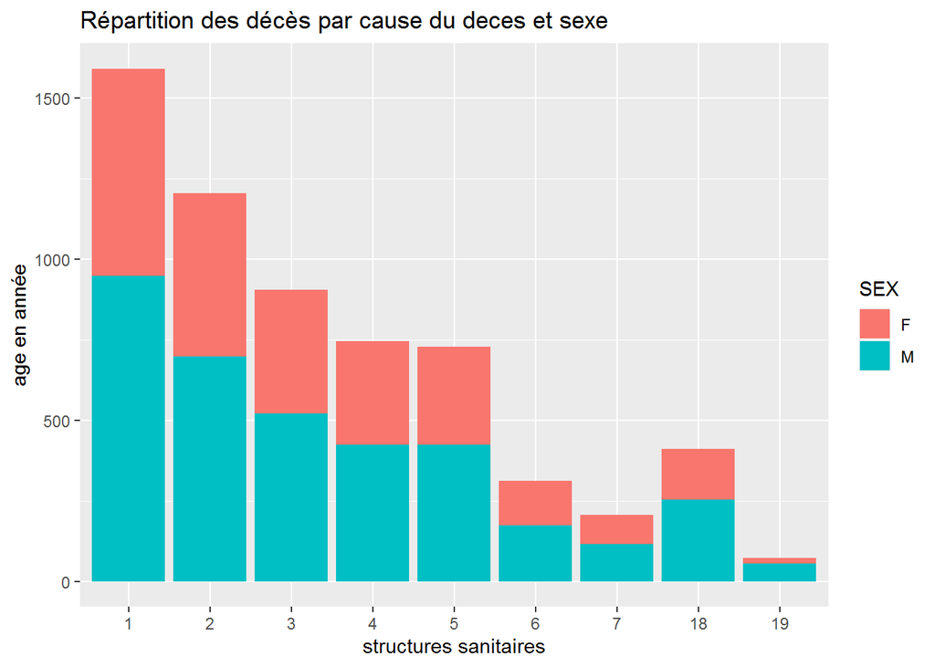

```r
ggplot(data = data) +
  geom_bar(aes(x = STRUCTURED, fill = SEX))+
  labs(title = "Répartition des décès par cause du deces et sexe",
       x = "structures sanitaires",
       y = "age en année")
```

### le service du deces et le sexe

```r
table(data$SERVICEHOSPIT, data$SEX)
```

```
##
##         F    M
##   0    49   79
##   1     5    6
##   2    34   43
##   3     0    1
##   4     0    0
##   5    28   12
##   6   178  287
##   7   176  248
##   8     6    9
##   9     3    1
##   10  499  726
##   11    1    4
##   12    0    1
##   14    0    0
##   15   64   74
##   16   78   95
##   17    0    0
##   18  201  267
##   19    0    1
##   20  988 1354
##   21  252  387
##   24    0    1
##   25    4   13
```

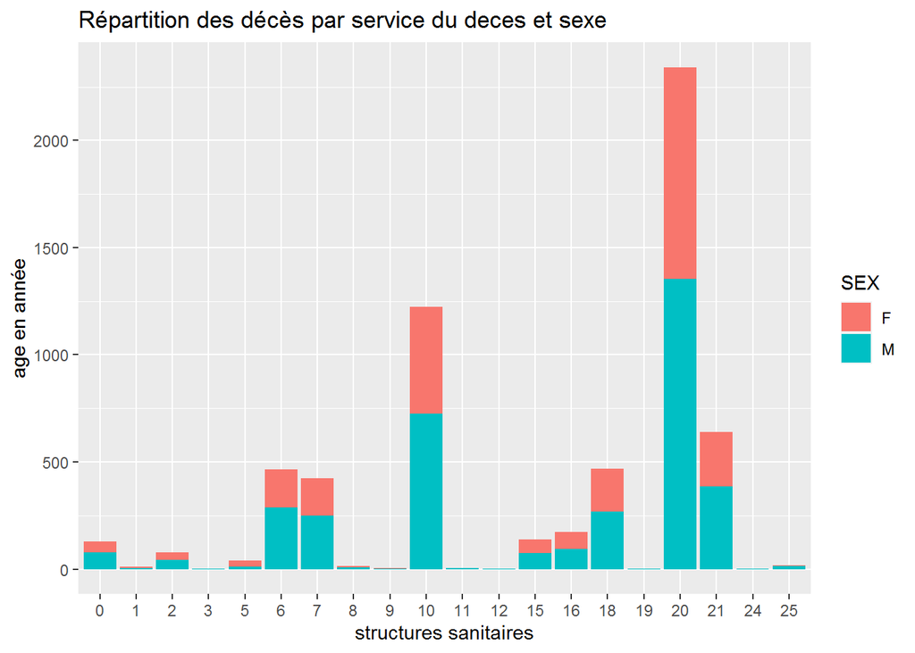

```r
ggplot(data = data) +
  geom_bar(aes(x = SERVICEHOSPIT, fill = SEX))+
  labs(title = "Répartition des décès par service du deces et sexe",
       x = "structures sanitaires",
       y = "age en année") #+theme_bw()
```

## 3.2 repartition des deces par CIM10 et sexe

```r
table(data$CODECIM0, data$SEX)
```

```
##
##        F   M
##   0  468 669
##   1  120 150
##   2  116 125
##   3   16  22
##   4   44  60
##   5    2   1
##   6   29  46
##   8    0   2
##   9  393 509
##   10 556 842
##   11  59  61
##   12   0   3
##   13   4   4
##   14  50  74
##   15  11   5
##   16 329 496
##   17 115 122
##   18 215 310
##   19  31  71
##   20   7  36
##   21   1   1
```

```r
#table(data$CODECIM, data$SEX)
```

## 3.3 Croisement d’une variable quantitative et d’une variable qualitative

### 3.3.1 age et sexe

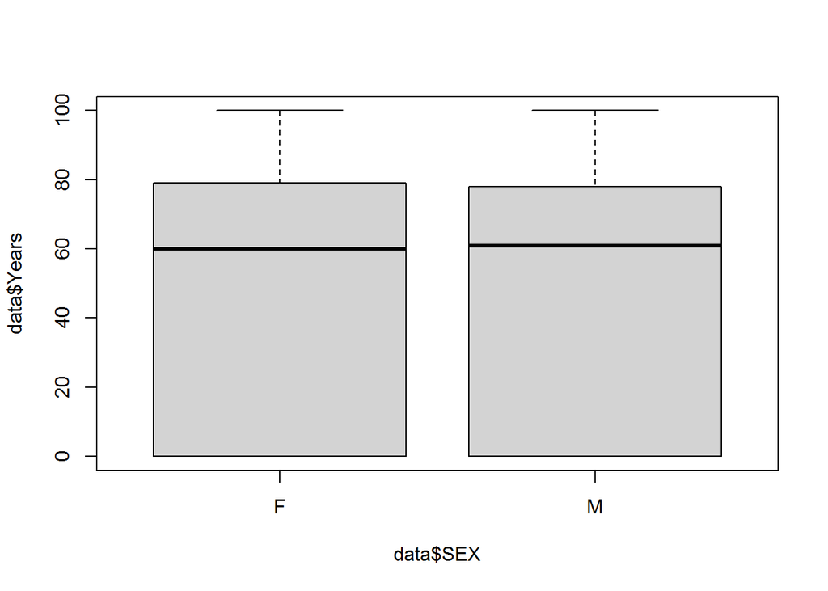

```r
boxplot(data$Years ~ data$SEX)
```

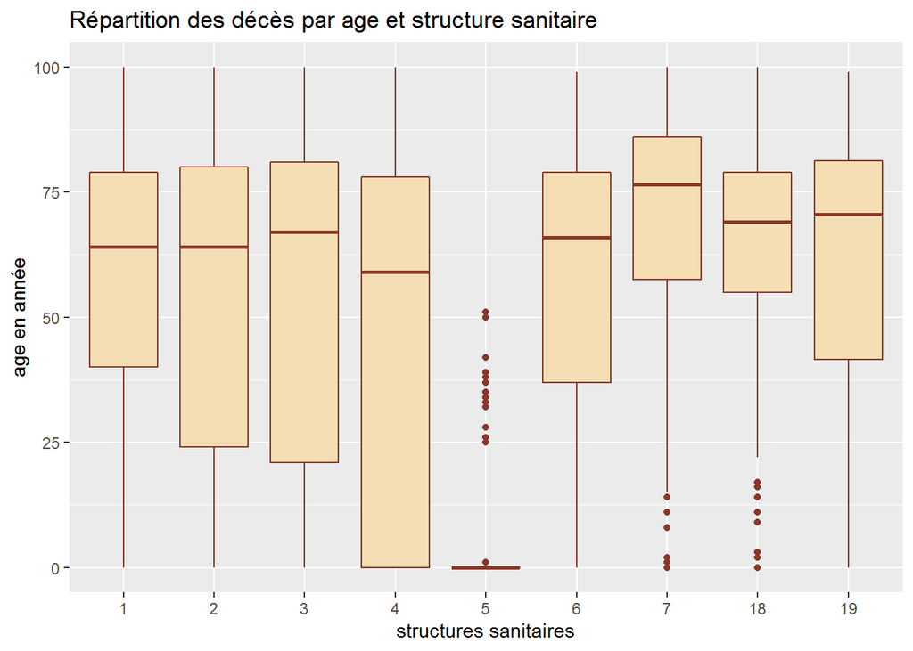

```r
ggplot(data = data,
       mapping = aes(x =STRUCTURED,y = Years)) +
  geom_boxplot(fill = "wheat", color = "tomato4")+
  labs(title = "Répartition des décès par age et structure sanitaire",
       x = "structures sanitaires",
       y = "age en année")
```

## 3.4 Croisement de deux variables quantitatives

```r
library(corrplot)
#str(data)
```

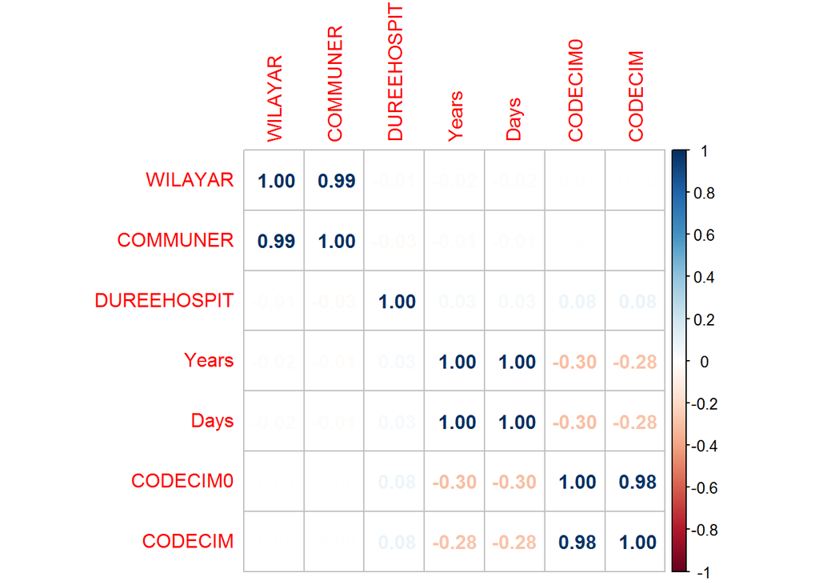

```r
data_n <- data %>%
  select(WILAYAR,COMMUNER,DUREEHOSPIT,Years,Days,CODECIM0,CODECIM)

M = cor(data_n)
corrplot(M, method = 'number') # colorful number
```

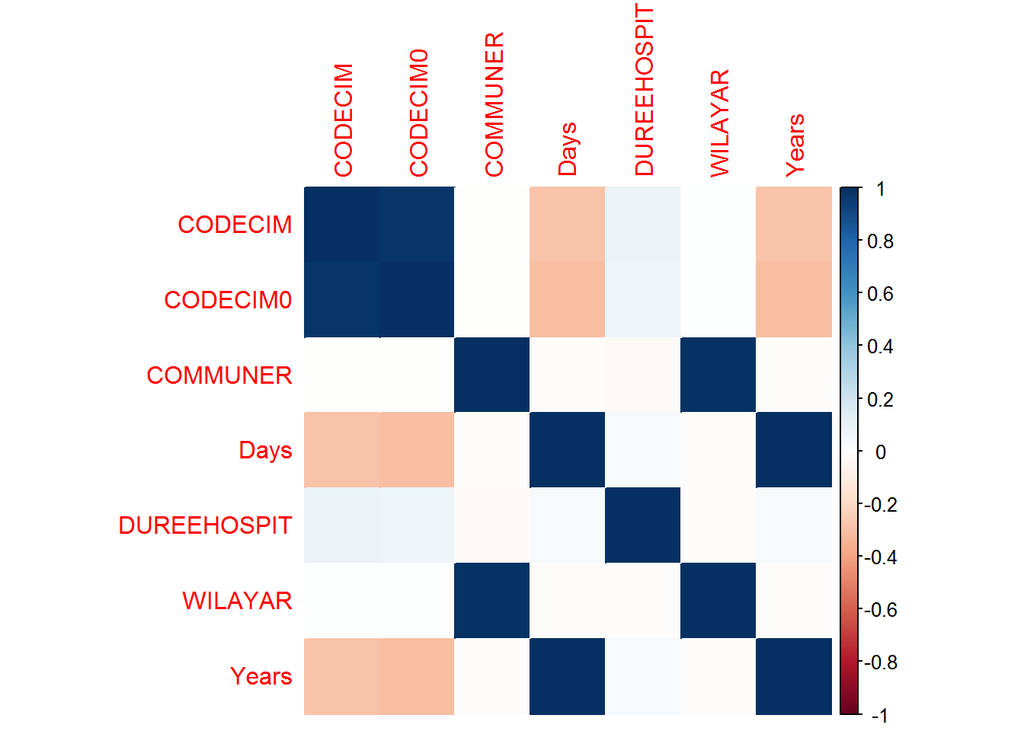

```r
corrplot(M, method = 'color', order = 'alphabet')
```

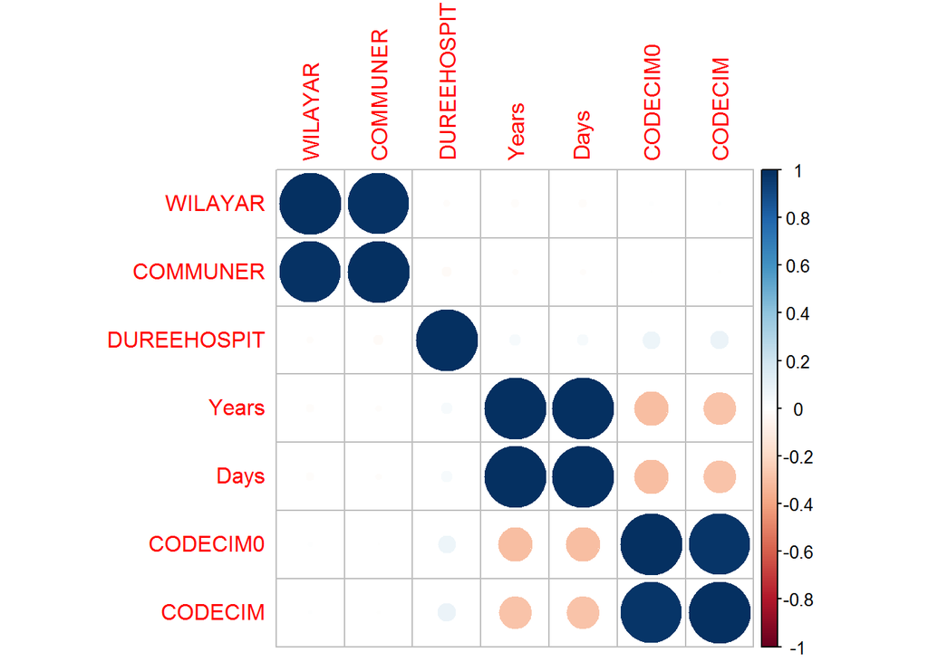

```r
corrplot(M) # by default, method = 'circle'
```

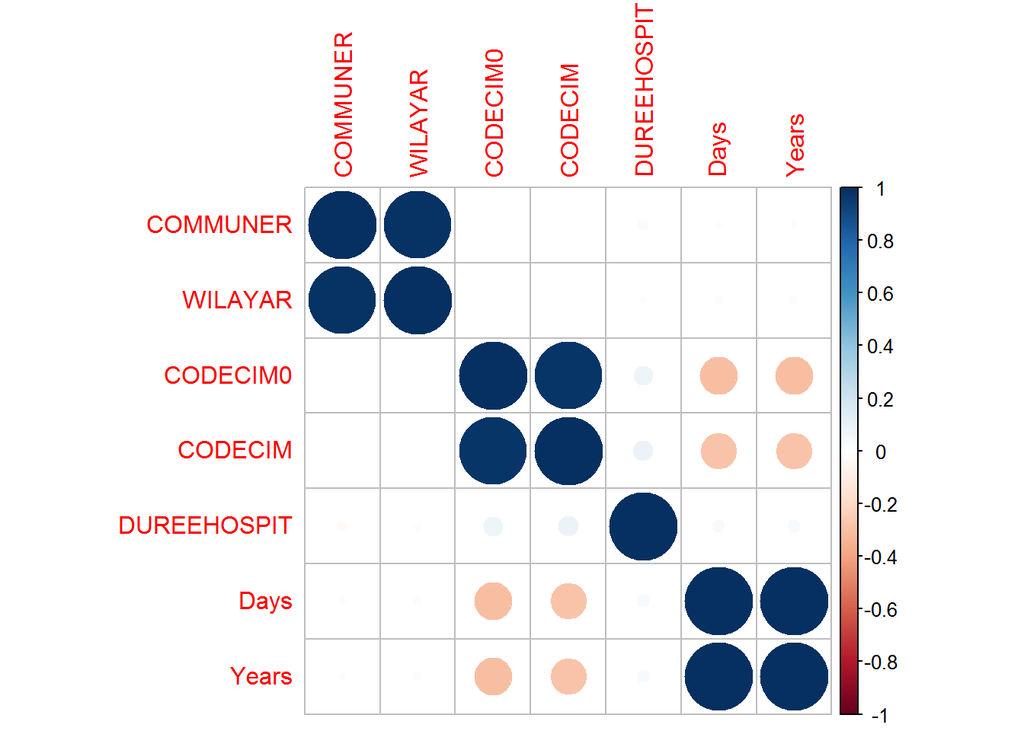

```r
corrplot(M, order = 'AOE') # after 'AOE' reorder
```

[figure not shown]

```r
corrplot(M, method = 'shade', order = 'AOE', diag = FALSE)
```

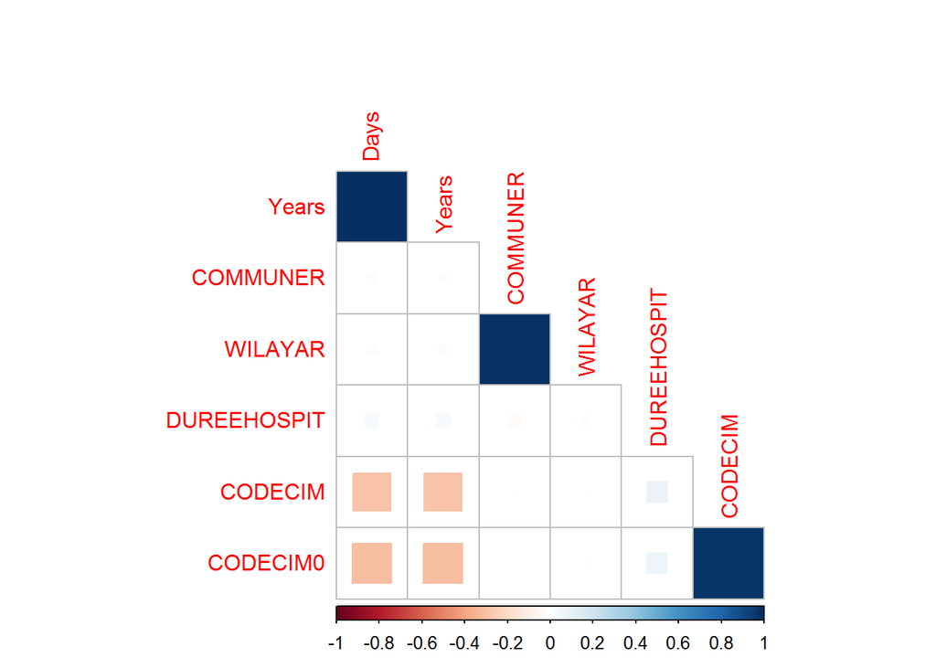

```r
corrplot(M, method = 'square', order = 'FPC', type = 'lower', diag = FALSE)
```

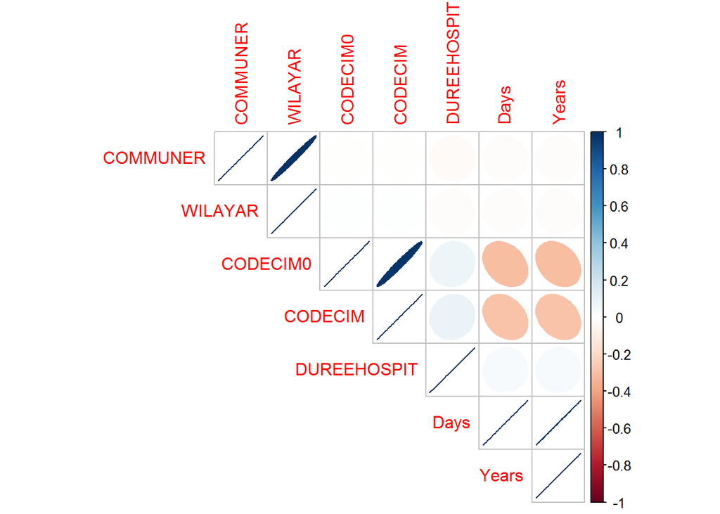

```r
corrplot(M, method = 'ellipse', order = 'AOE', type = 'upper')
```

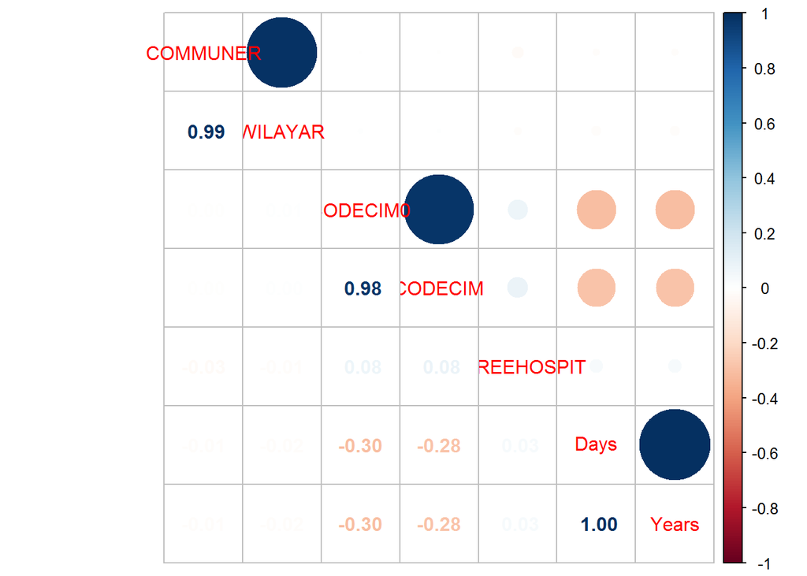

```r
corrplot.mixed(M, order = 'AOE')
```

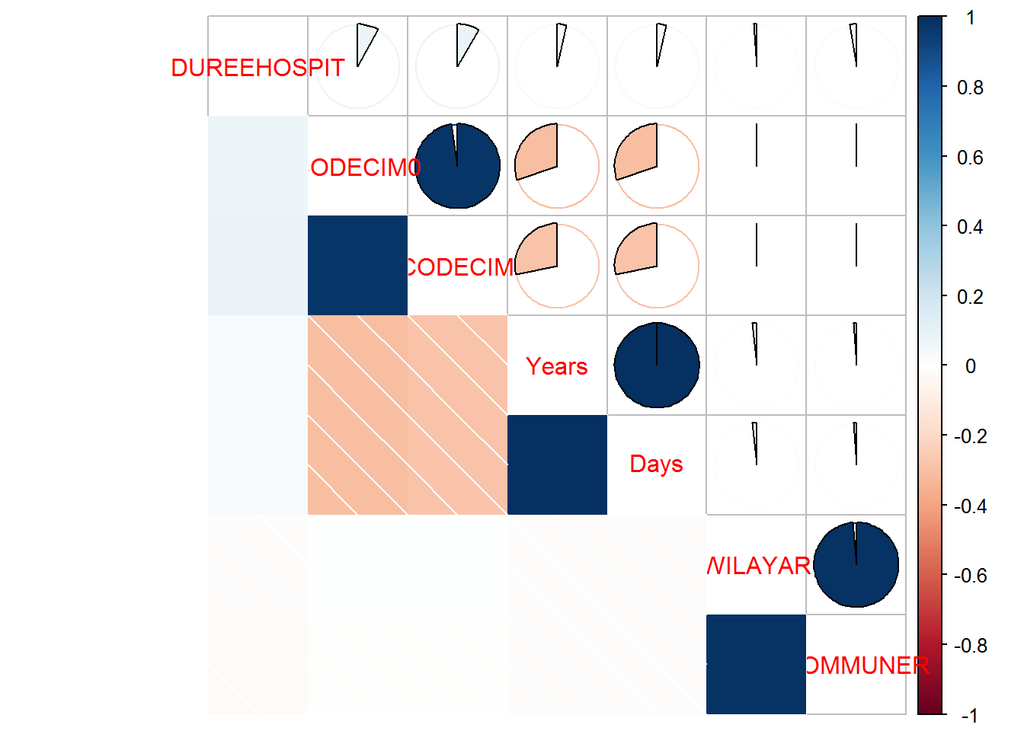

```r
corrplot.mixed(M, lower = 'shade', upper = 'pie', order = 'hclust')
```

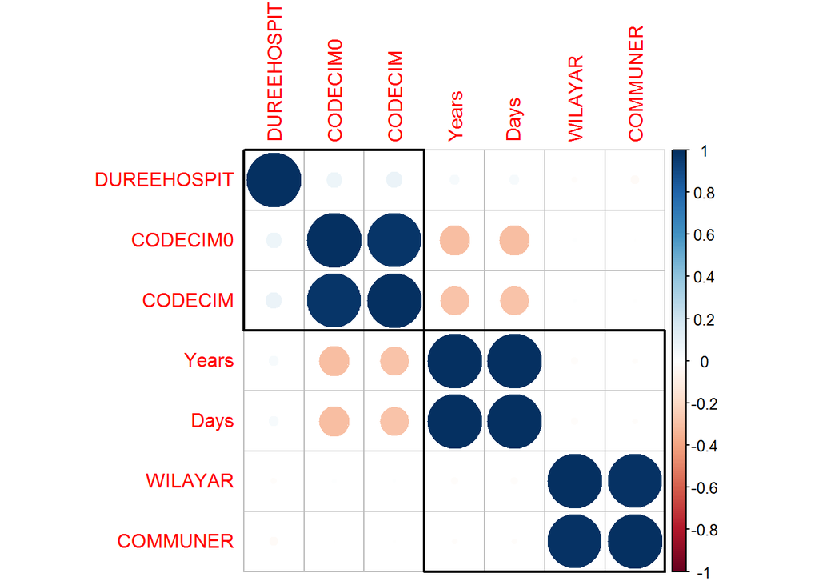

```r
corrplot(M, order = 'hclust', addrect = 2)
```

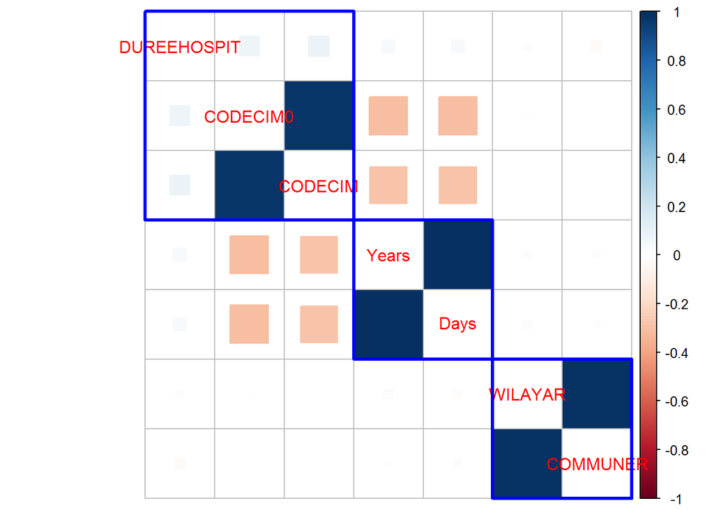

```r
corrplot(M, method = 'square', diag = FALSE, order = 'hclust',
         addrect = 3, rect.col = 'blue', rect.lwd = 3, tl.pos = 'd')
```

# 4 Analyse multivariée